# ゲノム・オミックスのデータ解析教室(R版)

その標本に対してヒストグラムを描いてみます。

```r
# 乱数を発生
max.sample <- 10^5
r <- sample(1:n.dist,max.sample,replace=TRUE)
R <- rep(NA,max.sample)
for(i in 1:max.sample){
  R[i] <- rnorm(1,ms[r[i]],sds[r[i]])
}
```

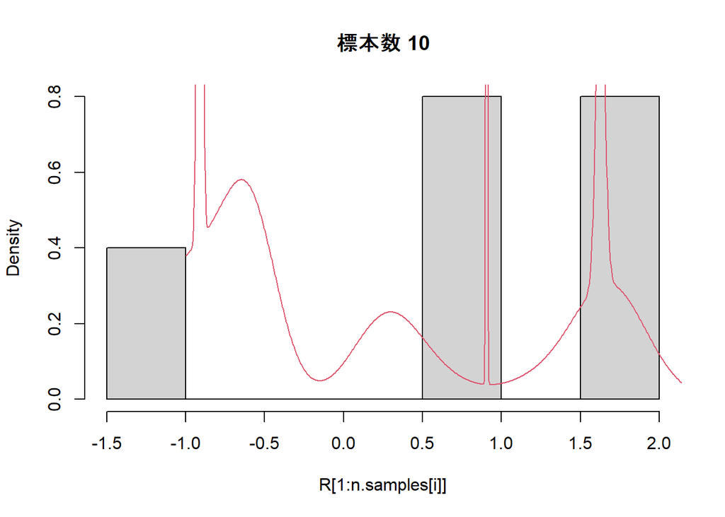

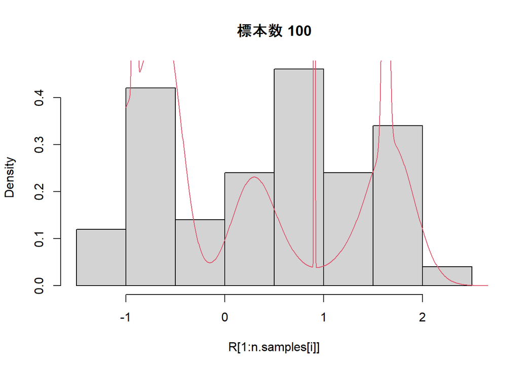

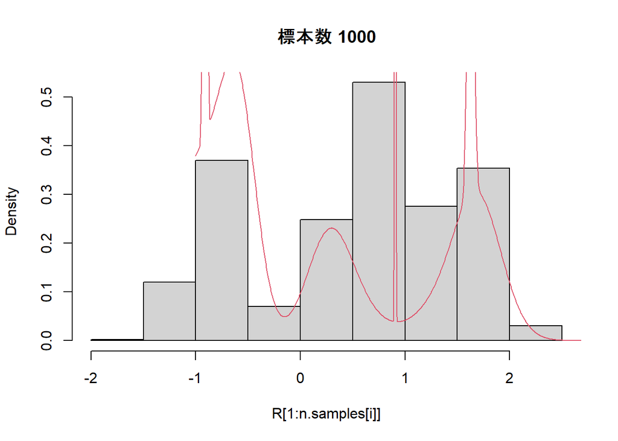

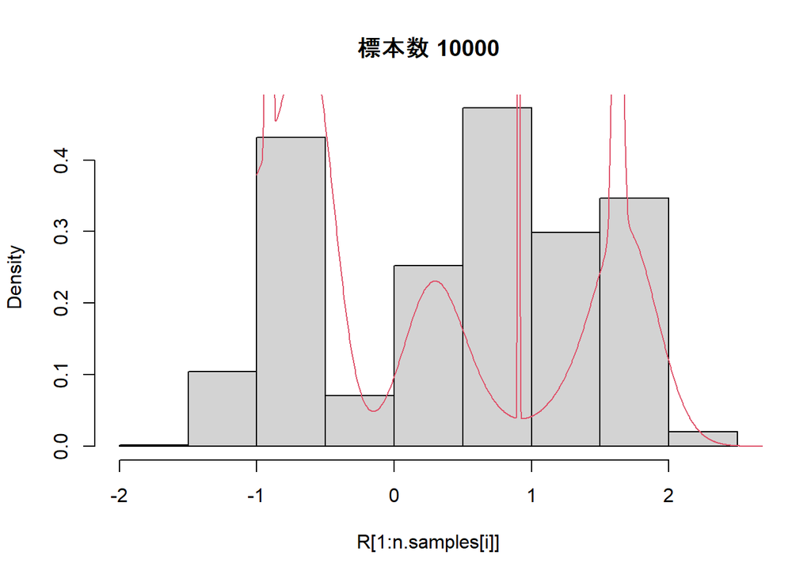

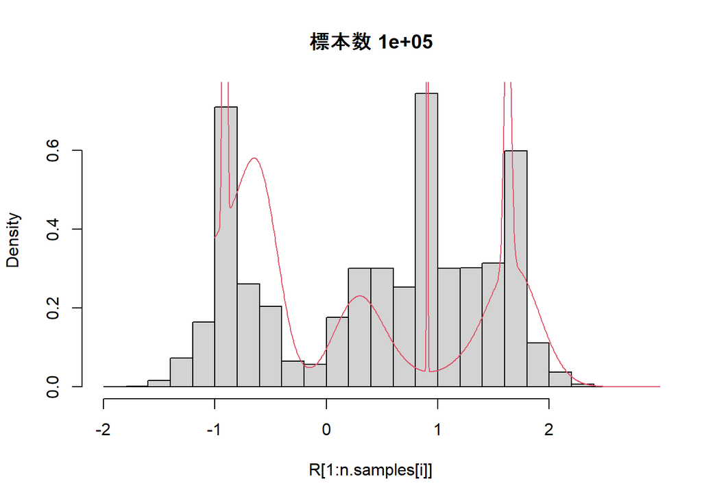

```r
n.samples <- c(10,100,1000,10000,100000)
for(i in 1:length(n.samples)){
  hist(R[1:n.samples[i]],freq=FALSE,main=paste("標本数",n.samples[i]))
  points(x,d,type="l",col=2)
}
```

標本数が増えるほど、ヒストグラムは複雑になり、「真の分布」に近づいていく様子が見えます。

標本数が十分に大きいならば、複雑なモデルを考えることが適当なことが判ります。 そして、ヒストグラムを描くというアプローチは、特段の処置を施さずに、標本数の増加に応じて結果が複雑になっています。

これが、ノンパラメトリックな手法の特徴です。

### 過剰適合とノンパラメトリックアプローチ

前の章では、過剰適合を防ぐためには複雑なモデルは避けるべきでした。

データ駆動型では、標本数に応じて複雑なモデルが得られて、それなりのメリットがある例が示されています。

モデルは複雑にしない方がよいのか、複雑にする方がよいのか、どちらなのでしょうか？

過剰適合を避けるために複雑なモデルを避けた場合と、標本数に応じて複雑なモデルを採用した場合とでは、フィッティングに当たっての立場が違うので、あたかも、相反する主張をしているようになるのです。

過剰適合を避けるために複雑なモデルを避けた場合には、多項式を使ったり、既知の確率密度分布を使ったりして、その重み係数のフィッティングをしました。

その際に採用した多項式や既知の分布が、背景にある真実にピタリと当て嵌まる場合には、標本数さえ増やせば過剰適合の心配は要りません。

しかしながら、多項式や既知の分布は単純な部品なので、それを使っても、「真実の複雑さ」を完全に説明することはできない(ことが多い)です。

そもそも完全に説明することができない前提なので、無理にフィッティングすると、過剰適合の問題が起きるのです。

この多項式や既知の分布はパラメターを用いて定義されているので、このアプローチはパラメトリックアプローチと言われます。 多項式の係数や正規分布の平均と標準偏差などがパラメタに当たります。

他方、ノンパラメトリックな手法では、パラメタを使って定義された部品を想定していません。データ量が増えるに従って、「自由に」複雑さを変えることが可能です。 この特徴は、背景に隠された「真実の複雑さ」を完全に説明する力の源となっています。

ゲノム・オミックス解析では、複雑な仕組みの解明を目指しているので、「真実の複雑さ」に迫るために、ノンパラメトリックな手法が活躍する場面が増えてきます。

では、ノンパラメトリックな手法であれば、過剰適合を心配しなくて良いのでしょうか？

答えは「否」です。真実の複雑さを説明する力が強いということは、それだけ柔軟にデータに寄り添うことができるということでもあり、過剰適合は問題になります。

### kNN法の例

ノンパラメトリックな手法の１つにkNN法(k-近傍法)というものがあります。

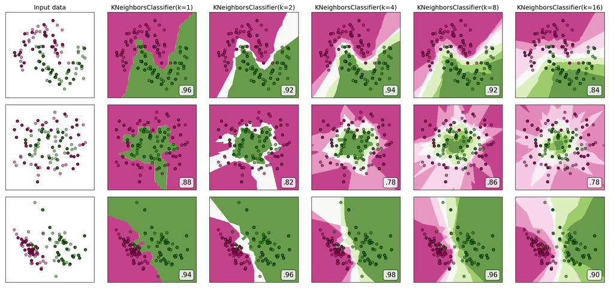

knn法による分類

(https://tomdlt.github.io/decks/2018_pydata/#1 より)

左端に２色の点が観測データとして表示されています。

kNN法により、空間(この場合は２次元平面)のそれぞれの場所が、赤らしいか、緑らしいかで色分けしています。

kNN法では、空間の各点(観測データがある場所も無い場所も)についての「赤らしさ・緑らしさ」に点をつけます。

- その点から1番,2番,...,k番目に近い観測データ点(k個の「近傍」の点)を確認します
- k個の「近傍」の点の赤・緑情報を確認し、赤ばかりなら、その点は赤の領域に属し、緑ばかりなら、その点は緑の領域に属すものとします
- 赤と緑が混在していたら、その割合に応じて、赤っぽいか・緑っぽいかを決めます

図では、kの値が左から1,2,4,8,16となっています。kの値が増えるほど、曖昧な領域(白っぽい領域)が増えています。

この例では、k=1ではっきり分けるのが良さそうに見えますが、次の例では、緑の線で細かくわけるのは「やりすぎ」で、黒い線で大雑把に分ける方が良さそうに見えます。

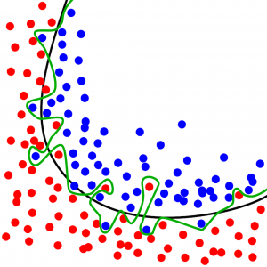

(https://towardsdatascience.com/model-selection-tuning-and-evaluation-in-k-nearest-neighbors-6d3024d78745 より)

kNN法ではkの値の選択によって複雑さの調整をすることができるので、それを過剰適合回避に利用することができます。

### 非線形次元削減 UMAP法でのkNN法

冒頭で紹介した非線形次元削減 UMAP法では、処理の一部にkNN法を使っています。

冒頭のRコードの中で以下のような実行条件の指定を行っていました。

```
custom.settings$n_neighbors = 3
custom.settings$n_neighbors = 10
```

このn_neighborsというのが、近傍の数という意味でkNNのkに相当します。

シングルセル・トランスクリプトーム解析をするにあたって、遺伝子発現のパターンを細胞同士で比較し、似ている方からk番目までの細胞を、「お隣」とみなすことにする、という設定です。

「お隣同士」とみなされた細胞ペアの間に線を引くことで、各細胞を頂点とするグラフが得られます。

グラフが与えられると、任意の２頂点間には、グラフ距離(グラフ上をたどって測る距離)が定義できるので、細胞同士の間に、グラフの形を考慮した距離が定まります。

UMAP法では、このグラフ距離を「細胞間の発現パターンの違いを表す値」とみなします。

グラフ上をたどる道筋は、うねうね・くねくねと曲がったものになるので、「違いの評価」が「非線形～曲がったもの」になっています。

kNN近傍法を使ってグラフを作ることから、同手法は非線形性を持った手法になっているのです。

UMAP法によりシングルセルを平面に描図する差異には、「グラフ視覚化アルゴリズム」が使われています。

グラフ視覚化とは、グラフは高次元にのたくった隣接関係を表しているが、それを２次元(や３次元)に表示するには、どうするとうまく視覚化できるかに関する研究分野で、色々な手法が開発されています。 高次元空間にあるグラフを無理に低次元に押し込めているので、このグラフ視覚化アルゴリズムも非線形な処理をしています。

## 終わりに

ゲノム・オミックスデータ解析の具体的な話題を例に取りながら、ゲノム・オミックスデータ解析の特徴を、データ自身の特徴と解析上の特徴に分けて説明しました。

また、ゲノム・オミックスのデータ解析は多段階になっており、また、データから読みだすメッセージに応じて、検定・推定・学習を使い分けているため、スタディで用いられる手法は、スタディごとにバリエーションを持って来ます。

したがって、特定の論文に使われる手法のフローをなぞって確認すると、その論文の手法についての理解は深まるものの、別の論文を開くと、全く別の手法が使われていることに気づき、また一から勉強し直しとなって、やる気がそがれるかも知れません。

ですので、この「解析教室」では、解析フローを構成するパーツは一見すると違った姿をしていますが、すべてに共通する考え方があると言う点を強調して説明することを試みました。

その試みが成功したか失敗したかは判りませんが、少しでもゲノム・オミックスデータ解析手法の理解の助けになればと思います。